# BikeShare

## Introduction

I wanted to demonstrate some basic exploratory data analysis techniques using R for the Kaggle Bike Share dataset.

Let’s load a bunch of libraries we’ll need.

```r
library(lubridate)
library(reshape2)
library(plyr)
```

```r
library(ggplot2)
library(scales)
#library(zoo)
```

## Reading and preparing the data

Read in training data and check out the dataframe structure

```r
train <- read.csv("./BikeShareData/train.csv")
str(train)
```

```
## 'data.frame':    10886 obs. of  12 variables:
##  $ datetime  : Factor w/ 10886 levels "2011-01-01 00:00:00",..: 1 2 3 4 5 6 7 8 9 10 ...
##  $ season    : int  1 1 1 1 1 1 1 1 1 1 ...
##  $ holiday   : int  0 0 0 0 0 0 0 0 0 0 ...
##  $ workingday: int  0 0 0 0 0 0 0 0 0 0 ...
##  $ weather   : int  1 1 1 1 1 2 1 1 1 1 ...
##  $ temp      : num  9.84 9.02 9.02 9.84 9.84 ...
##  $ atemp     : num  14.4 13.6 13.6 14.4 14.4 ...
##  $ humidity  : int  81 80 80 75 75 75 80 86 75 76 ...
##  $ windspeed : num  0 0 0 0 0 ...
##  $ casual    : int  3 8 5 3 0 0 2 1 1 8 ...
##  $ registered: int  13 32 27 10 1 1 0 2 7 6 ...
##  $ count     : int  16 40 32 13 1 1 2 3 8 14 ...
```

```r
summary(train)
```

```
##                 datetime         season         holiday
##  2011-01-01 00:00:00:    1   Min.   :1.000   Min.   :0.00000
##  2011-01-01 01:00:00:    1   1st Qu.:2.000   1st Qu.:0.00000
##  2011-01-01 02:00:00:    1   Median :3.000   Median :0.00000
##  2011-01-01 03:00:00:    1   Mean   :2.507   Mean   :0.02857
##  2011-01-01 04:00:00:    1   3rd Qu.:4.000   3rd Qu.:0.00000
##  2011-01-01 05:00:00:    1   Max.   :4.000   Max.   :1.00000
##  (Other)            :10880
##    workingday        weather           temp           atemp
##  Min.   :0.0000   Min.   :1.000   Min.   : 0.82   Min.   : 0.76
##  1st Qu.:0.0000   1st Qu.:1.000   1st Qu.:13.94   1st Qu.:16.66
##  Median :1.0000   Median :1.000   Median :20.50   Median :24.24
##  Mean   :0.6809   Mean   :1.418   Mean   :20.23   Mean   :23.66
##  3rd Qu.:1.0000   3rd Qu.:2.000   3rd Qu.:26.24   3rd Qu.:31.06
##  Max.   :1.0000   Max.   :4.000   Max.   :41.00   Max.   :45.45
##
##     humidity        windspeed          casual         registered
##  Min.   :  0.00   Min.   : 0.000   Min.   :  0.00   Min.   :  0.0
##  1st Qu.: 47.00   1st Qu.: 7.002   1st Qu.:  4.00   1st Qu.: 36.0
##  Median : 62.00   Median :12.998   Median : 17.00   Median :118.0
##  Mean   : 61.89   Mean   :12.799   Mean   : 36.02   Mean   :155.6
##  3rd Qu.: 77.00   3rd Qu.:16.998   3rd Qu.: 49.00   3rd Qu.:222.0
##  Max.   :100.00   Max.   :56.997   Max.   :367.00   Max.   :886.0
##
##      count
##  Min.   :  1.0
##  1st Qu.: 42.0
##  Median :145.0
##  Mean   :191.6
##  3rd Qu.:284.0
##  Max.   :977.0
##
```

Datetime came in as a factor. Convert to a POSIXct date. A few of the factors came in as integers. Let’s convert them too.

```r
train$datetime <- as.POSIXct(train$datetime)
train$season <- as.factor(train$season)
train$holiday <- as.factor(train$holiday)
train$workingday <- as.factor(train$workingday)
train$weather <- as.factor(train$weather)
```

Each row is an hour. However, we don’t know if we get a row for an hour with zero bike rentals. We should check this. If we are going to do analysis by hour, we need the zeroes (else our estimates will be biased high). One strategy for doing this is to create a “seeded” dataframe having all the hourly datetime values and then merge this dataframe with our existing train dataframe. Then we can fill in the other columns in the rows that had no bike share data. Also, since we only have data from the first nineteen days of each month, we need to remove the datetimes after the 19th from the seeded dataframe.

First for convenience, let’s add some date part columns - hour, DOW, month, day, year. Notice that for the date field, we are first using `trunc()`, which returns a POSIXlt date object. However, `plyr` strangeness can result when using POSIXlt instead of POSIXct objects. Hence, we make it POSIXct. See my [hselab post on using R for datetime group by analysis.](http://hselab.org/using-r-instead-of-excel-for-analyzing-recovery-room-data.html)

```r
train$month <- factor(month(train$datetime),ordered = TRUE)
train$day <- factor(mday(train$datetime),ordered = TRUE)
train$year <- factor(year(train$datetime),ordered = TRUE)
train$dayofweek <- factor(wday(train$datetime),ordered = TRUE)
train$hour <- factor(hour(train$datetime),ordered = TRUE)
train$date <- as.POSIXct(trunc(train$datetime, "day"))
```

Now use `table` for some counts to check for missing rows.

```r
table(train$hour)
```

```
##
##   0   1   2   3   4   5   6   7   8   9  10  11  12  13  14  15  16  17
## 455 454 448 433 442 452 455 455 455 455 455 455 456 456 456 456 456 456
##  18  19  20  21  22  23
## 456 456 456 456 456 456
```

```r
table(train$day)
```

```
##
##   1   2   3   4   5   6   7   8   9  10  11  12  13  14  15  16  17  18
## 575 573 573 574 575 572 574 574 575 572 568 573 574 574 574 574 575 563
##  19
## 574
```

```r
table(train$day,train$hour)
```

```
##
##       0  1  2  3  4  5  6  7  8  9 10 11 12 13 14 15 16 17 18 19 20 21 22
##   1  24 24 24 24 23 24 24 24 24 24 24 24 24 24 24 24 24 24 24 24 24 24 24
##   2  24 24 24 22 24 23 24 24 24 24 24 24 24 24 24 24 24 24 24 24 24 24 24
##   3  24 24 23 23 23 24 24 24 24 24 24 24 24 24 24 24 24 24 24 24 24 24 24
##   4  24 24 24 23 23 24 24 24 24 24 24 24 24 24 24 24 24 24 24 24 24 24 24
##   5  24 24 24 23 24 24 24 24 24 24 24 24 24 24 24 24 24 24 24 24 24 24 24
##   6  24 23 24 22 24 23 24 24 24 24 24 24 24 24 24 24 24 24 24 24 24 24 24
##   7  24 24 23 23 24 24 24 24 24 24 24 24 24 24 24 24 24 24 24 24 24 24 24
##   8  24 24 23 23 24 24 24 24 24 24 24 24 24 24 24 24 24 24 24 24 24 24 24
##   9  24 24 24 24 23 24 24 24 24 24 24 24 24 24 24 24 24 24 24 24 24 24 24
##   10 24 24 24 21 23 24 24 24 24 24 24 24 24 24 24 24 24 24 24 24 24 24 24
##   11 24 24 23 21 20 24 24 24 24 24 24 24 24 24 24 24 24 24 24 24 24 24 24
##   12 24 24 24 22 23 24 24 24 24 24 24 24 24 24 24 24 24 24 24 24 24 24 24
##   13 24 24 23 24 24 23 24 24 24 24 24 24 24 24 24 24 24 24 24 24 24 24 24
```

[output cut: 27 more lines]

```r
ddply(train,.(dayofweek),summarize,sum(count))
```

```
##   dayofweek    ..1
## 1         1 285546
## 2         2 295296
## 3         3 291985
## 4         4 292226
## 5         5 306401
## 6         6 302504
## 7         7 311518
```

Looks like there are a pretty small number of missing hourly rows.

Before we deal with this, let’s do some date level analysis.

### Counts by Date

We’ll use the `plyr` package. Let’s start by creating a new dataframe that has stats by date (instead of by hour).

```r
riders_by_date <- ddply(train,.(date,season,holiday,workingday),summarize,
                        numriders = sum(count),
                        numcasual = sum(casual),
                        numreg = sum(registered))

riders_by_date$month <- month(riders_by_date$date)
riders_by_date$day <- mday(riders_by_date$date)
riders_by_date$year <- year(riders_by_date$date)
riders_by_date$dayofweek <- wday(riders_by_date$date)
```

Easy now to check if all days of month appear the same number of times. If so, no missing dates.

```r
mdaycounts <- ddply(riders_by_date,.(day),summarize,nummdays = length(day))
summary(mdaycounts$nummdays)
```

```
##    Min. 1st Qu.  Median    Mean 3rd Qu.    Max.
##      24      24      24      24      24      24
```

So, every day of month appears 24 times. No missing dates. However, we likely do have missing hours. What about numbers of weekdays?

```r
wdaycounts <- ddply(riders_by_date,.(dayofweek),summarize,numwdays = length(dayofweek))
wdaycounts
```

```
##   dayofweek numwdays
## 1         1       66
## 2         2       65
## 3         3       65
## 4         4       65
## 5         5       65
## 6         6       64
## 7         7       66
```

Different number of weekdays. We have to make sure that we **take averages over dates** when grouping by day of week.

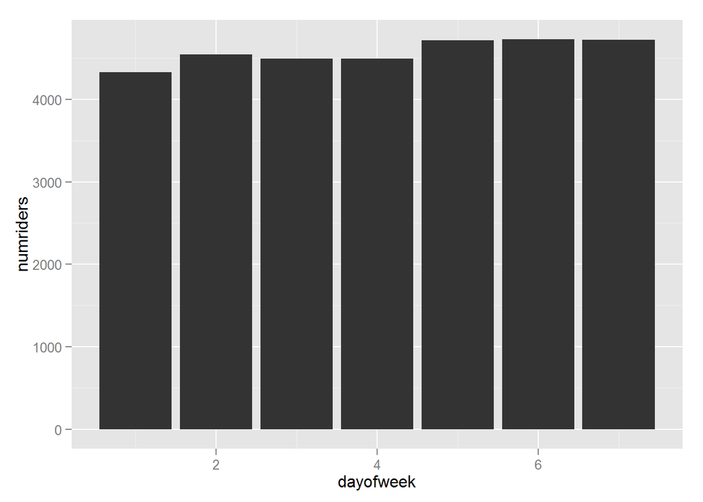

```r
ggplot(data=ddply(riders_by_date,.(dayofweek),summarize,numriders=mean(numriders))) + aes(x=dayofweek,y=numriders) + geom_bar(stat="identity")
```

```r
hourcounts <- ddply(train,.(date),summarize,numhours = length(count))
summary(hourcounts$numhours)
```

```
##    Min. 1st Qu.  Median    Mean 3rd Qu.    Max.
##   12.00   24.00   24.00   23.87   24.00   24.00
```

### Filling in missing hourly rows

This is a commonly needed task with time related data. Our basic strategy is:

- Create a fully “seeded” dataframe at the hourly level.
- Merge this new dataframe with our existing dataframe.
- Fill in the missing data either by recoding or other imputation methods

If (when) we find missing rows needing zero counts, then we also need to fill in the other columns. This is relatively easy for things like season, holiday, and workingday. However, then we have to decide what to do with the weather related columns. Likely, some sort of interpolation will make sense.

#### Create a fully seeded table at the hour level

The `ISOdate` function makes it easy to create dates much like the Excel DATE() function. Notice the timezone argument, `tz`. For `tz=""` we get the current timezone. This will lead to trickiness related to daylight savings time. Let’s specify EST. That 0 in the first call to ISOdate is necessary to make sure it starts at midnight.

```r
seededhours <- seq(ISOdate(2011,1,1,0,tz="EST"), ISOdate(2012,12,19,23,tz="EST"), "hour")
table(hour(seededhours))
```

```
##
##   0   1   2   3   4   5   6   7   8   9  10  11  12  13  14  15  16  17
## 719 719 719 719 719 719 719 719 719 719 719 719 719 719 719 719 719 719
##  18  19  20  21  22  23
## 719 719 719 719 719 719
```

Let’s get rid of rows past the 19th of the month.

```r
seededhours <- seededhours[day(seededhours)<=19] # Filter out day > 19
table(day(seededhours)) # Check the counts by day
```

```
##
##   1   2   3   4   5   6   7   8   9  10  11  12  13  14  15  16  17  18
## 576 576 576 576 576 576 576 576 576 576 576 576 576 576 576 576 576 576
##  19
## 576
```

Convert the seededhours list into a dataframe.

```r
df_seededhours <- as.data.frame(seededhours)
names(df_seededhours)
```

```
## [1] "seededhours"
```

```r
names(df_seededhours)[1] <- "datetime"
```

#### Merge

Merge the two dataframes using a left outer join. The missing rows in train will have NA in the other columns. Here’s a [good post on using merge to do inner, outer, left outer and right outer joins](http://stackoverflow.com/questions/1299871/how-to-join-data-frames-in-r-inner-outer-left-right)

```r
train <- merge(df_seededhours, train, by = "datetime",all.x = TRUE)
```

#### Fill in missing data

For the time related convenience fields, let’s just recompute them all.

```r
train$month <- factor(month(train$datetime),ordered = TRUE)
train$day <- factor(mday(train$datetime),ordered = TRUE)
train$year <- factor(year(train$datetime),ordered = TRUE)
train$dayofweek <- factor(wday(train$datetime),ordered = TRUE)
train$hour <- factor(hour(train$datetime),ordered = TRUE)
train$date <- as.POSIXct(trunc(train$datetime, "day"))
```

For season, let’s just recode the whole dataframe:

```r
train$season[train$month <= 3] <- 1
train$season[train$month > 3 & train$month <= 6] <- 2
train$season[train$month > 6 & train$month <= 9] <- 3
train$season[train$month > 9] <- 4
```

For the rider counts, zero them out.

```r
train$casual[is.na(train$casual)] <- 0
train$count[is.na(train$count)] <- 0
train$registered[is.na(train$registered)] <- 0
```

For the holidays, let’s create a master list of holidays and use that to update the NAs.

```r
holidays <- riders_by_date$date[riders_by_date$holiday==1]
```

```r
train$datetime[is.na(train$holiday) & train$date %in% holidays]
```

```
## [1] "2012-01-02 03:00:00 EST"
```

```r
train$holiday[is.na(train$holiday) & train$date %in% holidays] <- 1
# Any remaining holidays that are NA should be set to 0
train$holiday[is.na(train$holiday)] <- 0
```

what about the weather variables? It’s just a small number of records but we really should do some sort of imputed values. We’ll skip fo now.

## Exploratory data analysis

So, now we have fully filled out the dataframe and are ready for more analysis. Let’s clean up the workspace by getting rid of some things we no longer need.

```r
rm(df_seededhours,seededhours)
```

### Analyis of overall rider volume

Count riders by year, month. In this case, sums are fine since we have 19 days of data per month. However, in general, you should be cognizant of fact that often differences in monthly volumes of things can be attributed to the differing number of days per month and even the number of weekdays that happen to occur that month in a given year (hence, comparisons to same month last year should be questioned).

```r
riders_by_ym <- ddply(train,.(year,month),summarize,
                      total = sum(count),
                      casual = sum(casual),
                      registered = sum(registered),
                      ridedate = max(date))

riders_by_ym
```

```
##    year month  total casual registered   ridedate
## 1  2011     1  23552   2008      21544 2011-01-19
## 2  2011     2  32844   3776      29068 2011-02-19
## 3  2011     3  38735   7910      30825 2011-03-19
## 4  2011     4  50511  12229      38282 2011-04-19
## 5  2011     5  79617  15846      63771 2011-05-19
## 6  2011     6  89742  19591      70151 2011-06-19
## 7  2011     7  92780  26125      66655 2011-07-19
## 8  2011     8  83267  17573      65694 2011-08-19
## 9  2011     9  79053  18293      60760 2011-09-19
## 10 2011    10  79392  17135      62257 2011-10-19
## 11 2011    11  70868  10152      60716 2011-11-19
## 12 2011    12  61183   5079      56104 2011-12-19
## 13 2012     1  56332   5244      51088 2012-01-19
## 14 2012     2  66269   5521      60748 2012-02-19
## 15 2012     3  94766  17146      77620 2012-03-19
## 16 2012     4 116818  27576      89242 2012-04-19
## 17 2012     5 120399  25413      94986 2012-05-19
## 18 2012     6 130871  28964     101907 2012-06-19
## 19 2012     7 121620  24775      96845 2012-07-19
## 20 2012     8 130173  28287     101886 2012-08-19
## 21 2012     9 133257  27568     105689 2012-09-19
## 22 2012    10 127867  20922     106945 2012-10-19
## 23 2012    11 105491  15190      90301 2012-11-19
## 24 2012    12  98977   9621      89356 2012-12-19
```

Count riders by year, season

```r
riders_by_yseas <- ddply(train,.(year,season),summarize,
                      total = sum(count),
                      casual = sum(casual),
                      registered = sum(registered),
                      ridedate = max(date))

riders_by_yseas
```

```
##   year season  total casual registered   ridedate
## 1 2011      1  95131  13694      81437 2011-03-19
## 2 2011      2 219870  47666     172204 2011-06-19
## 3 2011      3 255100  61991     193109 2011-09-19
## 4 2011      4 211443  32366     179077 2011-12-19
## 5 2012      1 217367  27911     189456 2012-03-19
## 6 2012      2 368088  81953     286135 2012-06-19
## 7 2012      3 385050  80630     304420 2012-09-19
## 8 2012      4 332335  45733     286602 2012-12-19
```

Let’s do multiple line plots for casual, registered and total riders. First we’ll do it with data in its current “wide” format and use multiple geom_line() calls. After that we’ll do it via melting and a single geom_line() call. The melt approach is the “ggplotish”" way to do it. Adding series labels in a legend when multiple geom_line() calls are used turned out to be surprising tricky. This [post from StackOverflow](http://stackoverflow.com/questions/10349206/add-legend-to-ggplot2-line-plot) was useful.

Here’s with no legend.

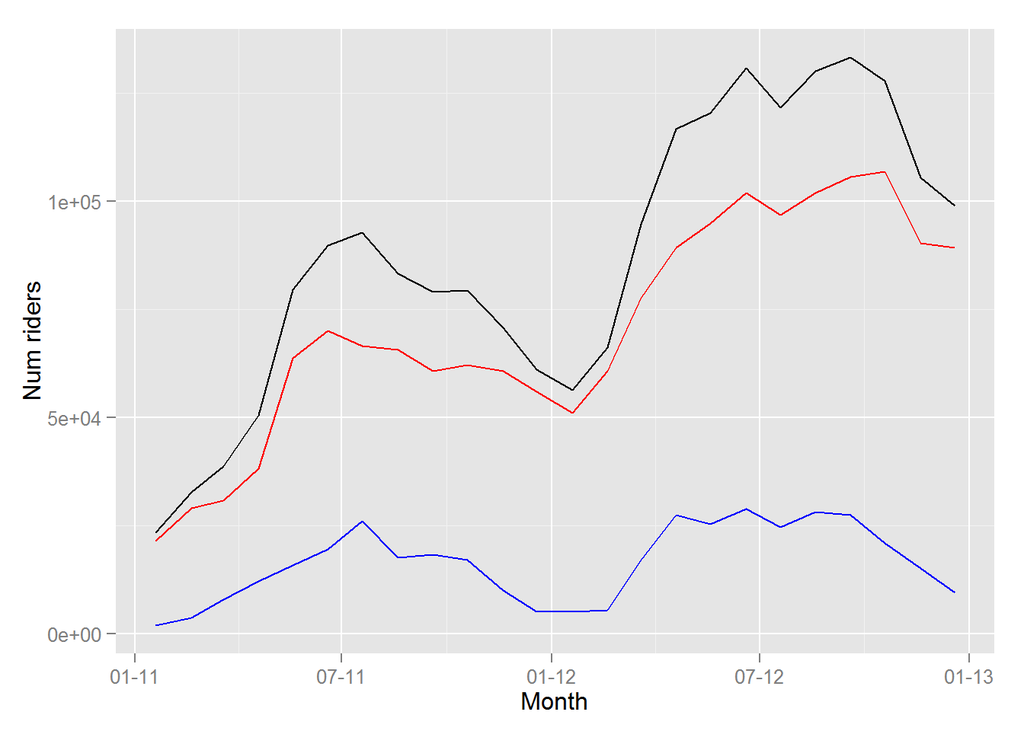

```r
ggplot() +
  geom_line(data = riders_by_ym, aes(x = as.Date(ridedate), y = total)) +
  geom_line(data = riders_by_ym, aes(x = as.Date(ridedate), y = casual), colour="blue") +
  geom_line(data = riders_by_ym, aes(x = as.Date(ridedate), y = registered), colour="red") +
  xlab('Month') +
  ylab('Num riders') + scale_x_date(labels = date_format("%m-%y"))
```

Here’s with a legend - see the StackOverflow post mentioned above for the details.

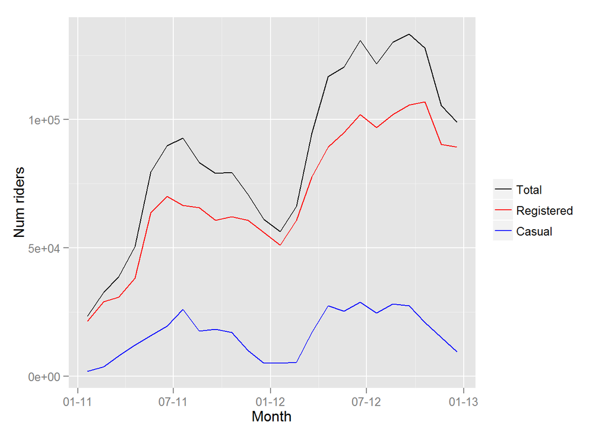

```r
ggplot() +
  geom_line(data = riders_by_ym, aes(x = as.Date(ridedate), y = total, colour="Total")) +
  geom_line(data = riders_by_ym, aes(x = as.Date(ridedate), y = casual, colour="Casual")) +
  geom_line(data = riders_by_ym, aes(x = as.Date(ridedate), y = registered, colour="Registered")) +
  scale_colour_manual("",
                      breaks = c("Total", "Registered", "Casual"),
                      values = c("Total"="black", "Registered"="red",
                                 "Casual"="blue")) +
  xlab('Month') +
  ylab('Num riders') + scale_x_date(labels = date_format("%m-%y"))
```

Melt the data data to get it into “long” format. For this we use the `reshape2` package. Notice how the number of rows increases - there is now one row per date and type of rider variable. And, there are new columns called RiderType and NumRiders.

```r
mlt_riders_by_ym <- melt(riders_by_ym,id.vars = c("year","month","ridedate"),
                         value.name = "NumRiders",
                         variable.name = "RiderType")
```

Now plot it using the RiderType column to control colour and series specification.

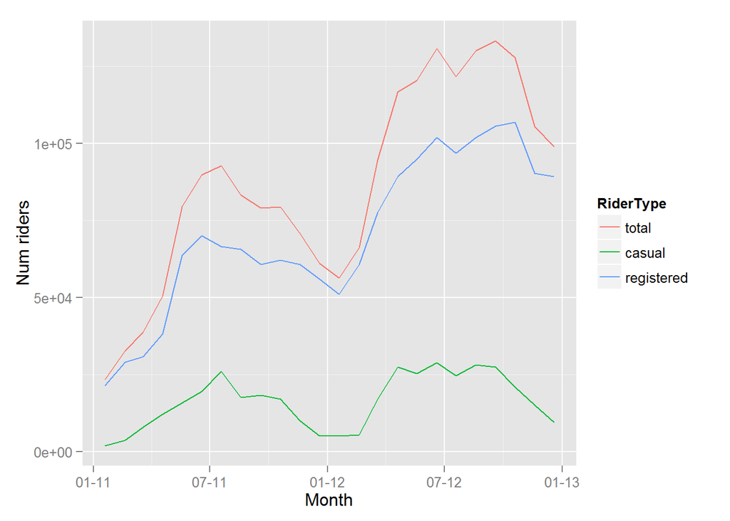

```r
plt_volume_ts <- ggplot() +
  geom_line(data = mlt_riders_by_ym, aes(x = as.Date(ridedate), y = NumRiders,
                                         colour = RiderType, group = RiderType)) +
  xlab('Month') +
  ylab('Num riders') + scale_x_date(labels = date_format("%m-%y"))

plt_volume_ts
```

Now plot it using the Year column to control colour and series specification and just show overall ridership. This allows comparison across years of both overall volume and time of year patterns.

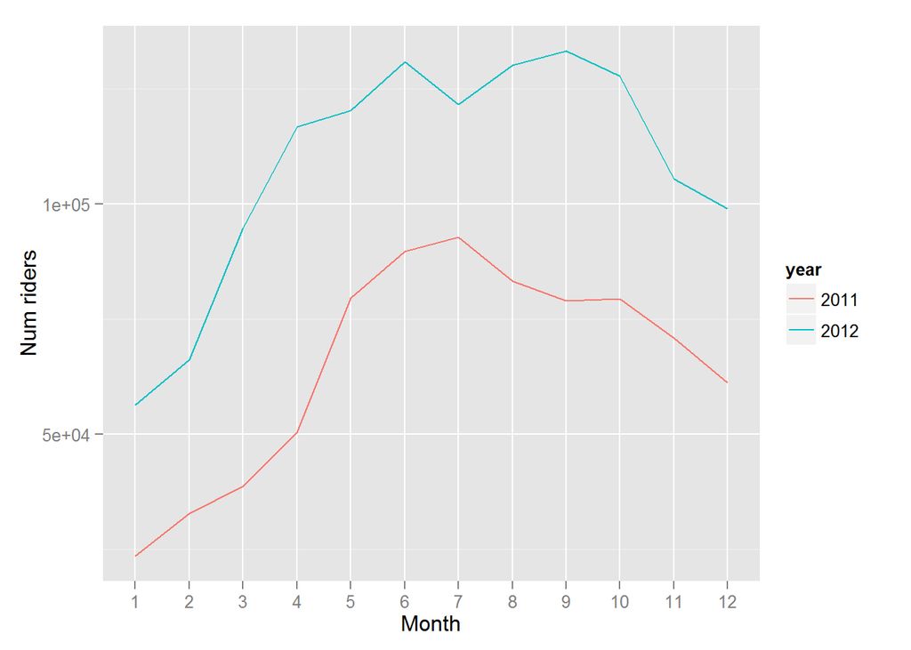

```r
plt_volume_stackedYears <- ggplot() +
  geom_line(data = riders_by_ym, aes(x=month, y=total,
                                         colour=year, group=year)) +
  xlab('Month') +
  ylab('Num riders')

plt_volume_stackedYears
```

Let’s add a linear trend line through the total riders.

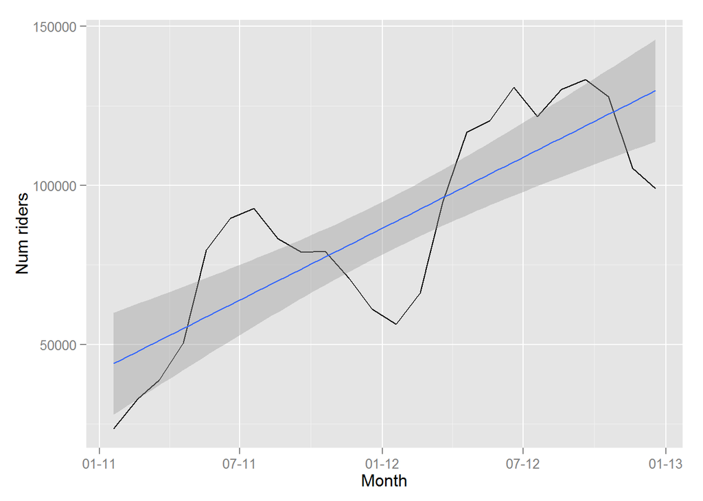

```r
ggplot(data = riders_by_ym, aes(x = as.Date(ridedate), y = total)) +
  geom_line() +
  geom_smooth(method = lm) +
  xlab('Month') +
  ylab('Num riders') + scale_x_date(labels = date_format("%m-%y"))
```

Is that trend statistically significant? Looks like it is.

```r
total_lm <- lm(data = riders_by_ym,total ~ ridedate)
summary(total_lm)
```

```
##
## Call:
## lm(formula = total ~ ridedate, data = riders_by_ym)
##
## Residuals:
##    Min     1Q Median     3Q    Max
## -32429 -16314   3588  15659  27235
##
## Coefficients:
##               Estimate Std. Error t value Pr(>|t|)
## (Intercept) -1.795e+06  2.904e+05  -6.184 3.18e-06 ***
## ridedate     1.420e-03  2.190e-04   6.483 1.60e-06 ***
## ---
## Signif. codes:  0 '***' 0.001 '**' 0.01 '*' 0.05 '.' 0.1 ' ' 1
##
## Residual standard error: 19560 on 22 degrees of freedom
## Multiple R-squared:  0.6564, Adjusted R-squared:  0.6408
## F-statistic: 42.03 on 1 and 22 DF,  p-value: 1.601e-06
```

### Day of week effects

```r
ddply(riders_by_date,.(dayofweek),summarize,mean(numriders))
```

```
##   dayofweek      ..1
## 1         1 4326.455
## 2         2 4543.015
## 3         3 4492.077
## 4         4 4495.785
## 5         5 4713.862
## 6         6 4726.625
## 7         7 4719.970
```

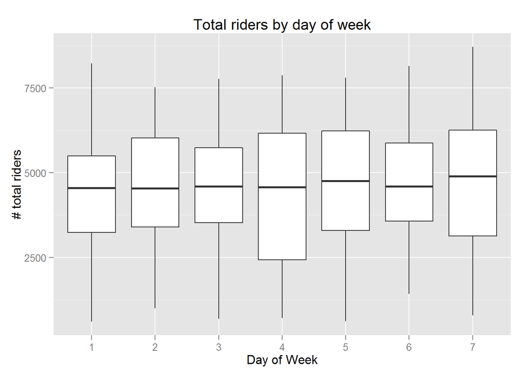

```r
ggplot(riders_by_date, aes(x = as.factor(dayofweek), y = numriders)) + geom_boxplot() +
  xlab('Day of Week') +
  ylab('# total riders') +
  ggtitle('Total riders by day of week')
```

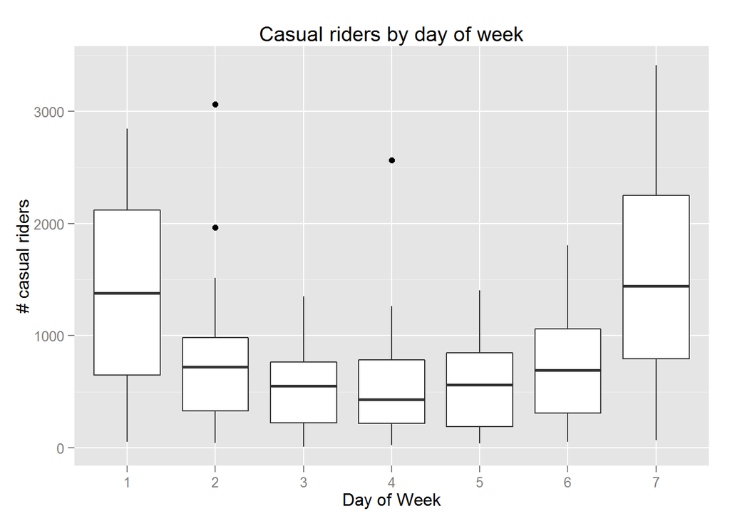

```r
ggplot(riders_by_date, aes(x = as.factor(dayofweek), y = numcasual)) + geom_boxplot() +
  xlab('Day of Week') +
  ylab('# casual riders') +
  ggtitle('Casual riders by day of week')
```

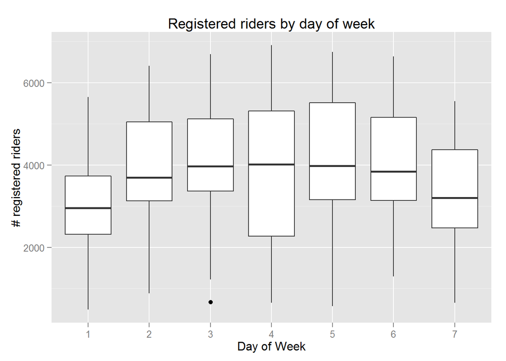

```r
ggplot(riders_by_date, aes(x = as.factor(dayofweek), y = numreg)) + geom_boxplot() +
  xlab('Day of Week') +
  ylab('# registered riders') +
  ggtitle('Registered riders by day of week')
```

Let’s melt by date.

```r
mlt_riders_by_date <- melt(riders_by_date,measure.vars = c("numriders","numcasual","numreg"),
                         id.vars = c("date","season","holiday","workingday","month","day","year","dayofweek"),
                         value.name = "NumRiders",
                         variable.name = "RiderType")
```

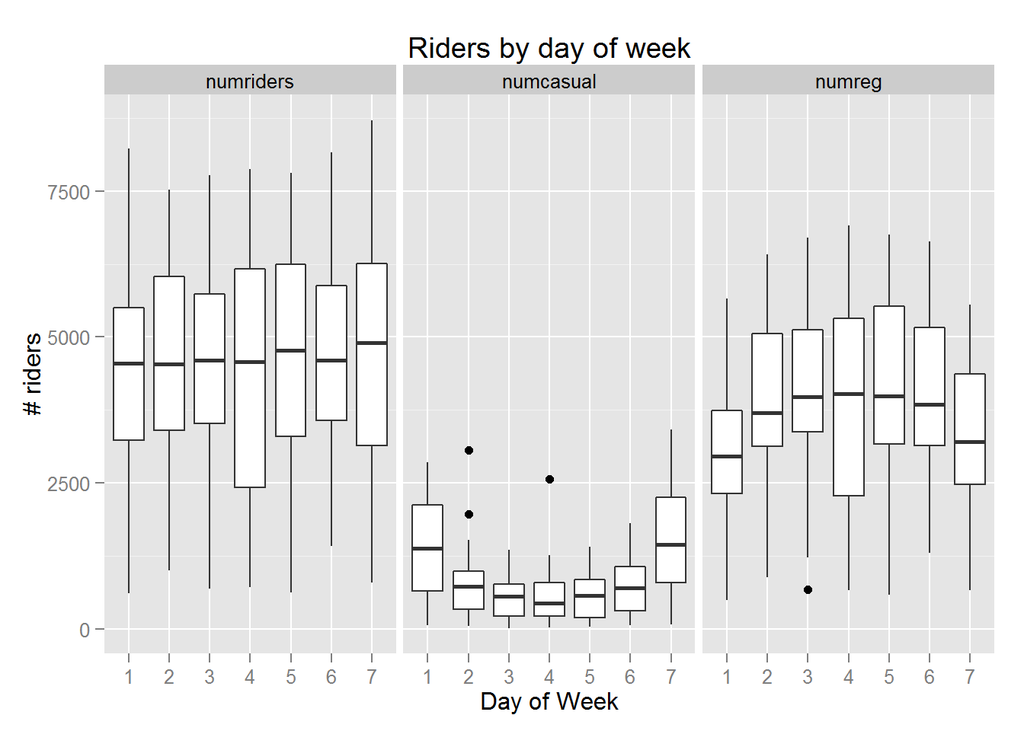

```r
ggplot(mlt_riders_by_date, aes(x = as.factor(dayofweek), y = NumRiders)) + geom_boxplot() + facet_grid(~RiderType) +
  xlab('Day of Week') +
  ylab('# riders') +
  ggtitle('Riders by day of week')
```

### Holidays

What is the average number of riders on holidays vs non-holidays

```r
ddply(riders_by_date,.(holiday),summarize,mean_riders_per_day=mean(numriders))
```

```
##   holiday mean_riders_per_day
## 1       0            4577.129
## 2       1            4446.769
```

```r
riders_by_holiday <- ddply(mlt_riders_by_date,.(holiday,RiderType),summarize,
                      mean = mean(NumRiders),
                      sd = sd(NumRiders),
                      pct_05 = quantile(NumRiders,0.05),
                      pct_95 = quantile(NumRiders,0.95))

riders_by_holiday
```

```
##   holiday RiderType      mean        sd pct_05 pct_95
## 1       0 numriders 4577.1287 1866.3233 1526.3 7566.4
## 2       0 numcasual  850.9345  690.8151   89.3 2346.8
## 3       0    numreg 3726.1941 1496.4277 1354.8 6270.6
## 4       1 numriders 4446.7692 2024.3048 1570.6 6783.2
## 5       1 numcasual 1167.0000  915.7509  177.0 2763.2
## 6       1    numreg 3279.7692 1412.4259 1377.4 5172.0
```

So, on holidays, the average number of casual riders is higher than on non-holidays. Makes sense.

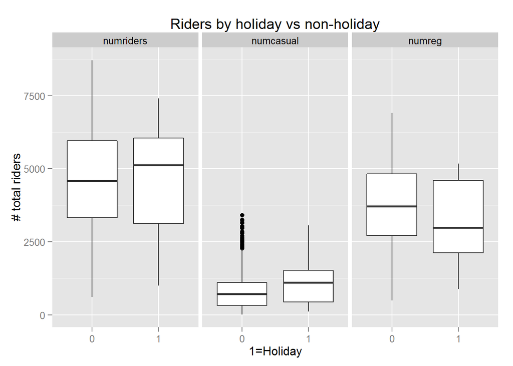

```r
ggplot(mlt_riders_by_date, aes(x = as.factor(holiday), y = NumRiders)) + geom_boxplot() + facet_grid(~RiderType) +
  xlab('1=Holiday') +
  ylab('# total riders') +
  ggtitle('Riders by holiday vs non-holiday')
```

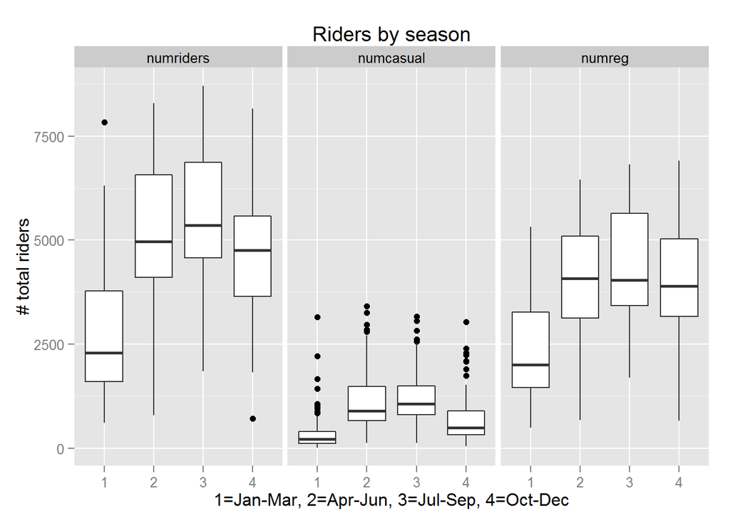

```r
ggplot(mlt_riders_by_date, aes(x = as.factor(season), y = NumRiders)) + geom_boxplot() + facet_grid(~RiderType) +
  xlab('1=Jan-Mar, 2=Apr-Jun, 3=Jul-Sep, 4=Oct-Dec') +
  ylab('# total riders') +
  ggtitle('Riders by season')
```

### Hour of day

I want to see boxplots by hour of day. That let’s us see both average and distribution of number of riders by time of day.

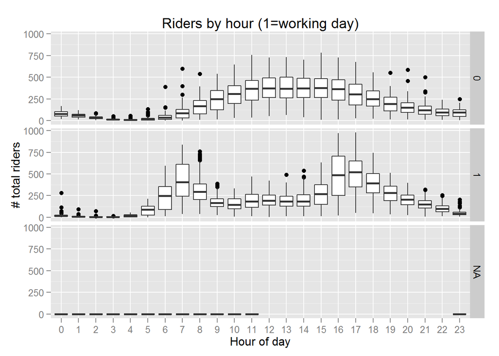

```r
ggplot(train, aes(x = as.factor(hour), y = count)) + geom_boxplot() + facet_grid(workingday~.) +
  xlab('Hour of day') +
  ylab('# total riders') +
  ggtitle('Riders by hour (1=working day)')
```

Now let’s facet by day of week.

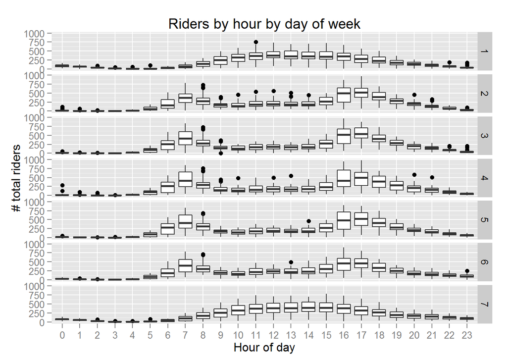

```r
ggplot(train, aes(x = as.factor(hour), y = count)) + geom_boxplot() + facet_grid(dayofweek~.) +
  xlab('Hour of day') +
  ylab('# total riders') +
  ggtitle('Riders by hour by day of week')
```

### Weather effects

Again, box plots provide a concise summary. We can’t simply sum up riders since we have widely different sample sizes for various weather conditions.

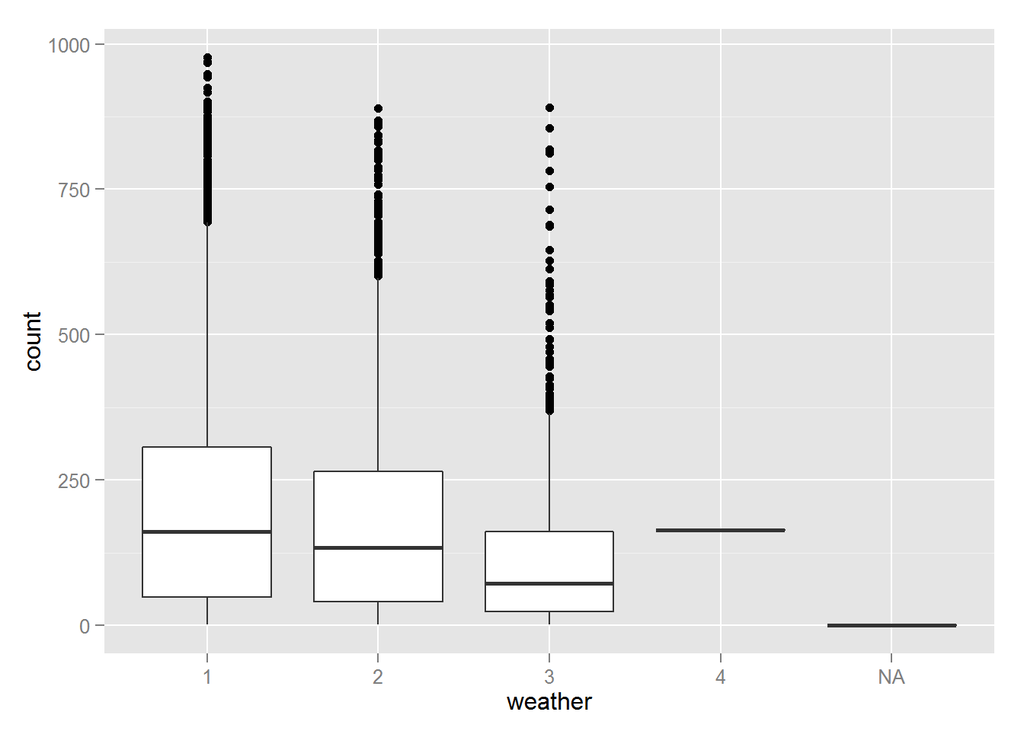

```r
ggplot(train, aes(x = weather, y = count)) + geom_boxplot()
```

Not surprisingly, better weather is associated with more riders.

Now let’s do scatter plots for each of the weather variables. We’ll make separate plots for casual and registered users.

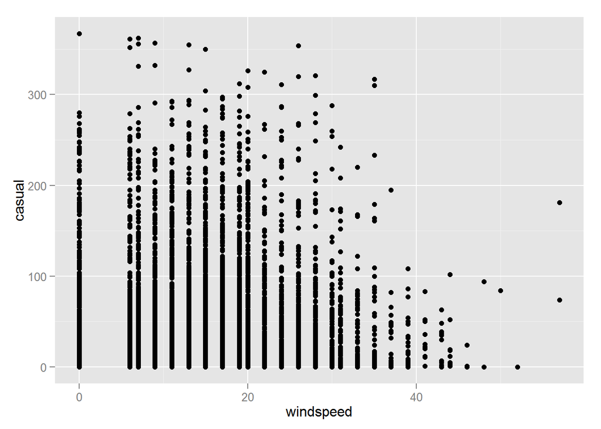

```r
ggplot(train, aes(x = windspeed, y = casual)) + geom_point()
```

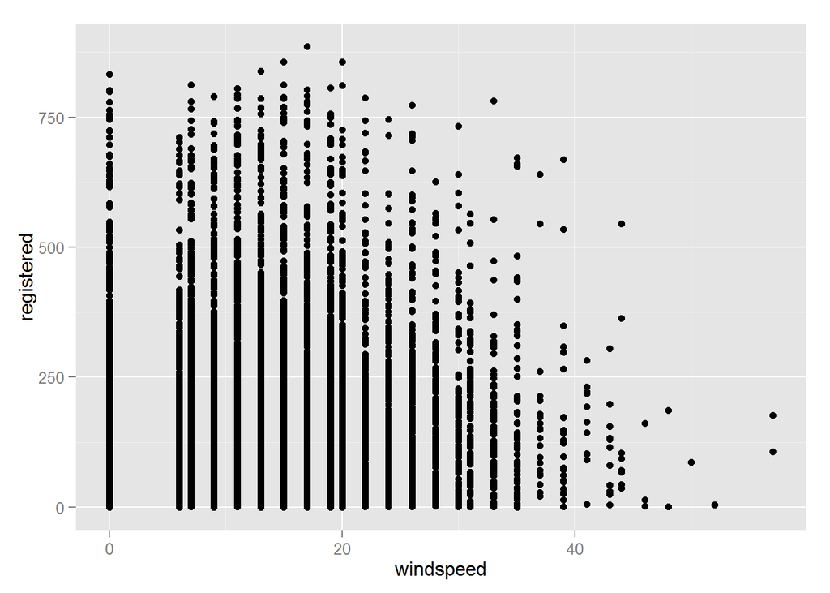

```r
ggplot(train, aes(x = windspeed, y = registered)) + geom_point()
```

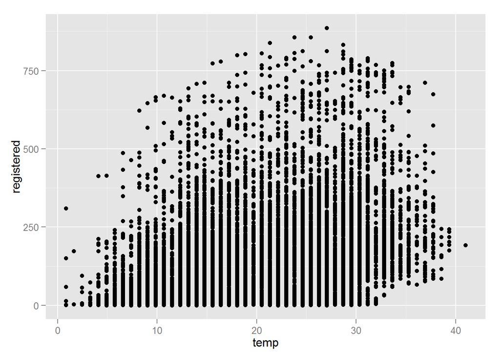

```r
ggplot(train, aes(x = temp, y = registered)) + geom_point()
```

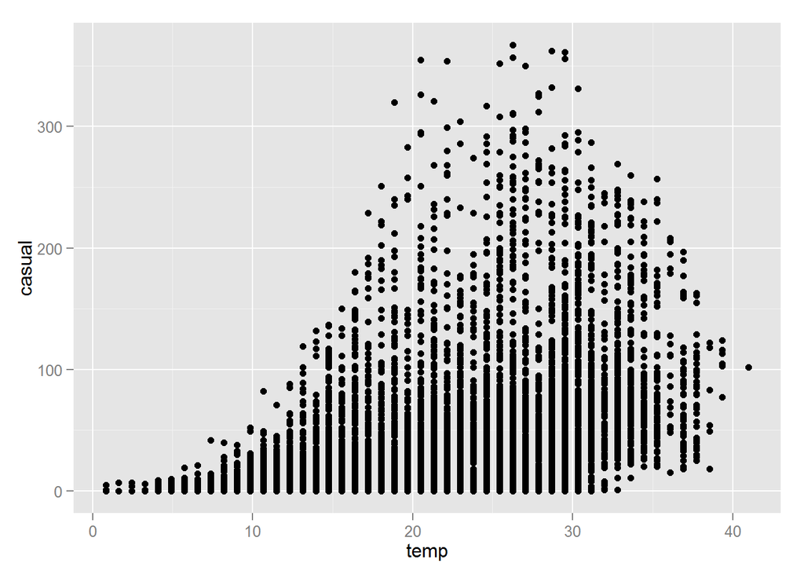

```r
ggplot(train, aes(x = temp, y = casual)) + geom_point()
```

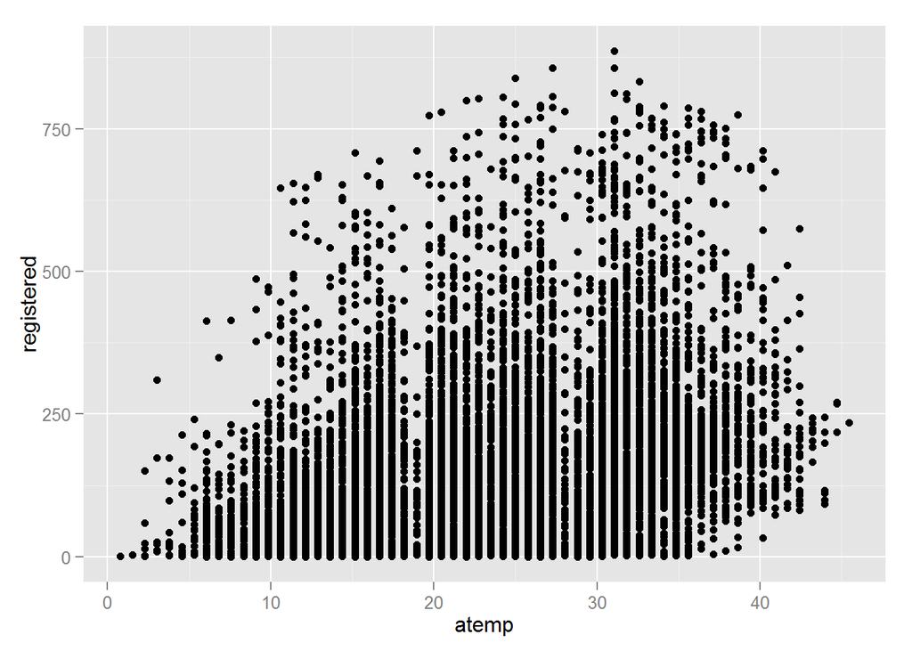

```r
ggplot(train, aes(x = atemp, y = registered)) + geom_point()
```

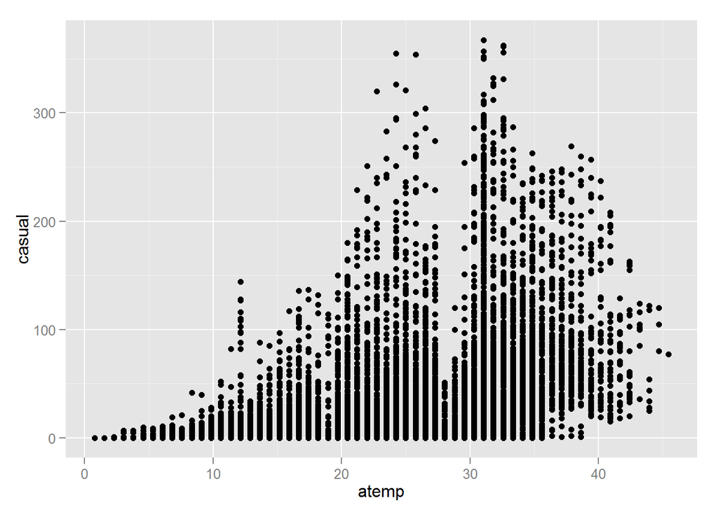

```r
ggplot(train, aes(x = atemp, y = casual)) + geom_point()
```

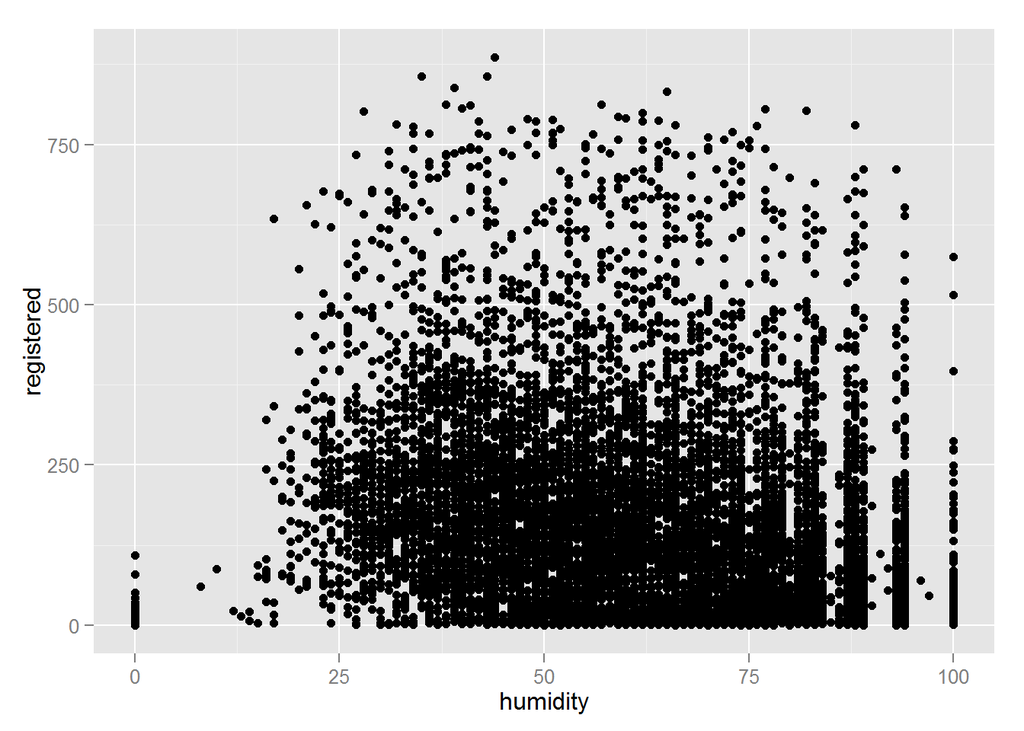

```r
ggplot(train, aes(x = humidity, y = registered)) + geom_point()
```

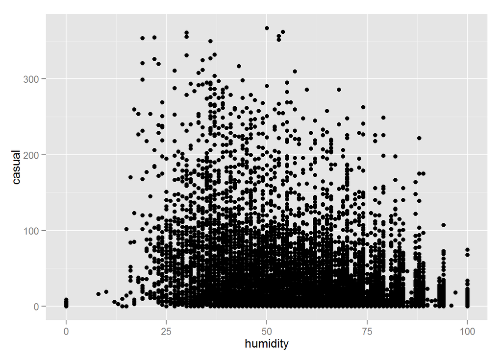

```r
ggplot(train, aes(x = humidity, y = casual)) + geom_point()
```

Let’s bin the weather variables so that we can do averages by bin.

```r
train$humcat <- cut(train$humidity, breaks = 10)
train$tempcat <- cut(train$temp, breaks = 15)
train$atempcat <- cut(train$atemp, breaks = 15)
train$windcat <- cut(train$windspeed, breaks = 15)
```

```r
avg_vol_hum <- ddply(train,.(humcat),summarize,
                      total = mean(count),
                      casual = mean(casual),
                      registered = mean(registered),
                      n = length(datetime))

avg_vol_wind <- ddply(train,.(windcat),summarize,
                      total = mean(count),
                      casual = mean(casual),
                      registered = mean(registered),
                      n = length(datetime))

avg_vol_temp <- ddply(train,.(tempcat),summarize,
                      total = mean(count),
                      casual = mean(casual),
                      registered = mean(registered),
                      n = length(datetime))

avg_vol_atemp <- ddply(train,.(atempcat),summarize,
                      total = mean(count),
                      casual = mean(casual),
                      registered = mean(registered),
                      n = length(datetime))
```

```r
avg_vol_hum
```

```
##       humcat     total    casual registered    n
## 1  (-0.1,10]  33.62500  3.375000   30.25000   24
## 2    (10,20] 245.61111 81.944444  163.66667   54
## 3    (20,30] 299.34783 72.741546  226.60628  414
## 4    (30,40] 287.50611 66.468586  221.03752 1146
## 5    (40,50] 234.46281 47.701373  186.76144 1748
## 6    (50,60] 207.46523 38.577263  168.88797 1812
## 7    (60,70] 186.78370 32.989674  153.79402 1840
## 8    (70,80] 153.23564 24.357702  128.87794 1532
## 9    (80,90] 123.04015 15.533045  107.50710 1619
## 10  (90,100]  78.55066  6.903084   71.64758  681
## 11      <NA>   0.00000  0.000000    0.00000   74
```

```r
avg_vol_wind
```

```
##         windcat    total    casual registered    n
## 1  (-0.057,3.8] 161.1815  29.81541   131.3661 1311
## 2     (3.8,7.6] 159.9921  28.34876   131.6433 1901
## 3    (7.6,11.4] 188.8661  34.25863   154.6075 2173
## 4   (11.4,15.2] 206.5422  38.67616   167.8661 2001
## 5     (15.2,19] 215.1837  40.97932   174.2044  822
## 6     (19,22.8] 212.3760  42.73377   169.6422 1540
## 7   (22.8,26.6] 224.2283  43.10039   181.1280  508
## 8   (26.6,30.4] 218.5470  46.98993   171.5570  298
## 9   (30.4,34.2] 197.1775  37.27219   159.9053  169
## 10    (34.2,38] 221.0500  43.28750   177.7625   80
## 11    (38,41.8] 180.5000  26.36842   154.1316   38
## 12  (41.8,45.6] 159.7000  25.75000   133.9500   20
## 13  (45.6,49.4]  96.6000  23.80000    72.8000    5
## 14  (49.4,53.2]  88.0000  42.00000    46.0000    2
## 15  (53.2,57.1] 269.5000 127.50000   142.0000    2
## 16         <NA>   0.0000   0.00000     0.0000   74
```

```r
avg_vol_temp
```

```
##        tempcat     total    casual registered    n
## 1   (0.78,3.5]  46.16000  1.320000   44.84000   25
## 2   (3.5,6.18]  54.09005  1.720379   52.36967  211
## 3  (6.18,8.86]  74.64241  3.700624   70.94179  481
## 4  (8.86,11.5]  89.65655  6.486717   83.16983 1054
## 5  (11.5,14.2] 137.77383 13.046794  124.72704 1154
## 6  (14.2,16.9] 165.49508 22.987489  142.50760 1119
## 7  (16.9,19.6] 167.71232 27.464154  140.24816 1088
## 8  (19.6,22.2] 193.48413 36.896032  156.58810 1260
## 9  (22.2,24.9] 227.13475 42.718338  184.41641  987
## 10 (24.9,27.6] 222.56410 49.821314  172.74279 1248
## 11 (27.6,30.3] 253.25974 57.145854  196.11389 1001
## 12   (30.3,33] 332.28010 80.376639  251.90346  839
## 13   (33,35.6] 344.62587 92.842657  251.78322  286
## 14 (35.6,38.3] 333.01942 87.495146  245.52427  103
## 15   (38.3,41] 276.64286 88.428571  188.21429   14
## 16        <NA>   0.00000  0.000000    0.00000   74
```

```r
avg_vol_atemp
```

```
##        atempcat     total     casual registered    n
## 1  (0.715,3.74]  49.82353  0.8235294   49.00000   17
## 2   (3.74,6.72]  61.34400  2.2240000   59.12000  125
## 3    (6.72,9.7]  64.89935  3.2207792   61.67857  308
## 4    (9.7,12.7]  93.28195  7.2911726   85.99078  759
## 5   (12.7,15.7] 111.07431  9.5633028  101.51101 1090
## 6   (15.7,18.6] 143.39008 15.2581852  128.13190 1069
## 7   (18.6,21.6] 175.87583 26.0853081  149.79052 1055
## 8   (21.6,24.6] 175.71743 31.9307818  143.78664 1228
## 9   (24.6,27.6] 196.33720 35.8075085  160.52969 1465
## 10  (27.6,30.6] 178.82695 31.5284553  147.29849  861
## 11  (30.6,33.5] 289.06242 69.5449438  219.51748 1602
## 12  (33.5,36.5] 301.37532 73.3015267  228.07379  786
## 13  (36.5,39.5] 336.49157 85.3848315  251.10674  356
## 14  (39.5,42.5] 328.29771 85.1755725  243.12214  131
## 15  (42.5,45.5] 279.61111 81.9444444  197.66667   18
## 16         <NA>   0.00000  0.0000000    0.00000   74
```

Create melted versions to facilitate stacked bar graphs of average rider volumes. For a few of the charts I included the sample size as a bar label. This reminds us that these averages are based on different sample sizes.

```r
mlt_avg_vol_atemp <- melt(avg_vol_atemp)
mlt_avg_vol_temp <- melt(avg_vol_temp)
mlt_avg_vol_hum <- melt(avg_vol_hum)
mlt_avg_vol_wind <- melt(avg_vol_wind)
```

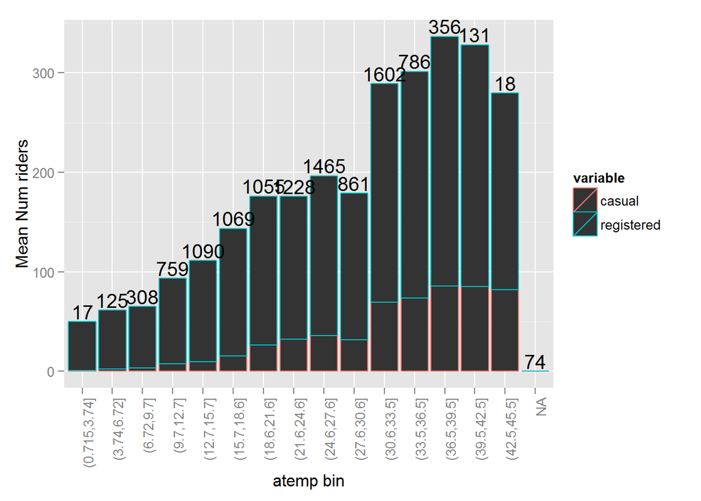

```r
labels = mlt_avg_vol_atemp[mlt_avg_vol_atemp$variable == 'n',3]
plt_avg_vol_atemp <- ggplot() +
  geom_bar(data = mlt_avg_vol_atemp[mlt_avg_vol_atemp$variable != 'n' & mlt_avg_vol_atemp$variable != 'total',], aes(x = atempcat, y = value,  colour = variable, group = variable), stat="identity") +
  xlab('atemp bin') +
  ylab('Mean Num riders') + theme(axis.text.x = element_text(angle = 90, hjust = 1)) +
   geom_text(data=mlt_avg_vol_atemp[mlt_avg_vol_atemp$variable == 'total',],aes(x=atempcat,y=value,label=labels,vjust=-0.2))

plt_avg_vol_atemp
```